# TP bioregionalisation avec les réseaux

Boris Leroy, UMR BOREA, Muséum National d’Histoire Naturelle

```r
# pak::pkg_install("bioRgeo/bioregion", ask = TRUE)

library(bioregion)
install_binaries(binpath = "c:/r")
```

# 1. Chargement des données (bases poissons et polygones spatialisés des bassins)

```r
# Packages
library(bioregion)
library(sf)
# Répertoire de travail
# setwd("d:/r/projects/Cours_Bioregionalisation/")

# Shapefiles
basins <- st_read("./data/data_cours/basin_simplif.shp")
```

```
## replacing null geometries with empty geometries
## Simple feature collection with 842 features and 9 fields (with 225 geometries empty)
## Geometry type: GEOMETRY
## Dimension:     XY
## Bounding box:  xmin: -135.2411 ymin: -40 xmax: 152.4369 ymax: 71.82438
## Geodetic CRS:  WGS 84
```

```r
# Occurrence databases
fishdb1 <- readRDS("./data/data_cours/fishdb1.RDS")
fishdb2 <- readRDS("./data/data_cours/fishdb2.RDS")
```

# 3. Rechercher les clusters sur le réseau

```r
fish_clusters1 <- netclu_infomap(net = fishdb1,
                                 weight = FALSE,
                                 binpath = "c:/r",
                                 numtrials = 100,
                                 show_hierarchy = TRUE,
                                 bipartite = TRUE,
                                 bipartite_version = FALSE,
                                 site_col = "Basin",
                                 species_col = "Species",
                                 seed = 123)
```

# 3.2. Première lecture et interprétation du résultat

```r
fish_clusters1
```

```
## Clustering results for algorithm : netclu_infomap
##  - Number of sites:  842
## Clustering results:
##  - Number of partitions:  4
##  - Partitions are hierarchical
##  - Number of clusters:  3 7 83 113
```

**Question** : combien de niveaux avez-vous ? Combien de clusters à chaque niveau ?

Il y a 4 niveaux. Au premier niveau, il y a 3 clusters ; au deuxième niveau il y a 7 clusters ; au troisième niveau, 83 clusters et au quatrième niveau, 113 clusters.

**Question** : combien y a-t-il de sites et d’espèces par cluster pour la première partition ? Qu’en déduisez-vous pour les régions biogéographiques ?

```r
summary(fish_clusters1)
```

```
##
## Summary of clustering results
## =============================
##
## Algorithm:  netclu_infomap
## Number of sites:  842
##   - Site nodes:  842
##   - Species nodes:  11030
## Number of bioregionalizations:  4
## Hierarchical clustering: Yes
##
## Bioregionalization 1: K_3
## -------------------------
## Total clusters:  3
## Top 3 clusters by size:
##   Cluster 1: 6080 items (562 sites, 5518 species)
##   Cluster 2: 5777 items (279 sites, 5498 species)
##   Cluster 3: 15 items (1 sites, 14 species)
##
## Bioregionalization 2: K_7
## -------------------------
## Total clusters:  7
## Top 7 clusters by size:
##   Cluster 2.1: 4863 items (156 sites, 4707 species)
##   Cluster 1.2: 2765 items (117 sites, 2648 species)
##   Cluster 1.1: 1915 items (212 sites, 1703 species)
##   Cluster 2.2: 914 items (123 sites, 791 species)
##   Cluster 1.3: 868 items (125 sites, 743 species)
##   Cluster 1.4: 532 items (108 sites, 424 species)
##   Cluster 3: 15 items (1 sites, 14 species)
##
## Bioregionalization 3: K_83
## --------------------------
## Total clusters:  83
## Top 10 clusters by size:
##   Cluster 2.1.2: 1142 items (1 sites, 1141 species)
##   Cluster 1.1.1: 967 items (67 sites, 900 species)
##   Cluster 2.1.4: 675 items (2 sites, 673 species)
##   Cluster 2.2.1: 629 items (92 sites, 537 species)
##   Cluster 1.2.4: 557 items (1 sites, 556 species)
```

[output cut: 63 more lines]

```
## │ ├─2.1.13 (n=75)
## │ ├─2.1.14 (n=52)
## │ ├─2.1.15 (n=59)
## │ ├─2.1.16 (n=70)
## │ ├─2.1.17 (n=59)
## │ ├─2.1.18 (n=25)
## │ └─... and 14 more
## └─2.2 (n=914)
##   ├─2.2.1 (n=629)
##   ├─2.2.2 (n=215)
##   └─2.2.3 (n=70)
##
## 3 (n=15)
## └─3 (n=15)
##   └─3 (n=15)
```

Il y a deux clusters principaux avec près de 6000 noeuds (ce sont des super-régions), et un tout petit cluster de 15 noeuds.

Pour le deuxième niveau : 4 clusters principaux (4 grandes régions) dans le cluster 1, 2 clusters principaux dans le cluster 2, et toujours notre petit cluster marginal.

# 4. Analyser séparément les sites et les espèces

**Question :** Faites un histogramme du nombre de sites par cluster dans les deux premières partitions. Faites la même pour le nombre d’espèces par cluster.

La commande summary donne déjà cette information, mais on peut aussi l’obtenir avec la fonction `count` du package `plyr`.

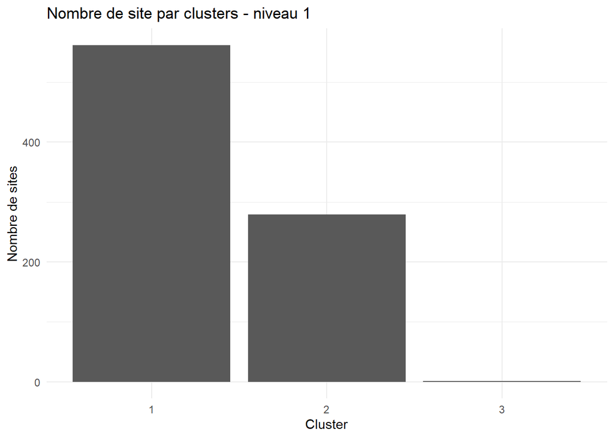

```r
library(ggplot2)
clusters1 <- fish_clusters1$clusters
site_clusters1 <- clusters1[which(clusters1$ID %in% fishdb1$Basin), ]
sites_p1 <- plyr::count(site_clusters1[2])
ggplot(sites_p1, aes(x = K_3, y = freq)) +
  geom_bar(stat = "identity") +
  labs(x = "Cluster", y = "Nombre de sites") +
  theme_minimal() +
  ggtitle("Nombre de site par clusters - niveau 1")
```

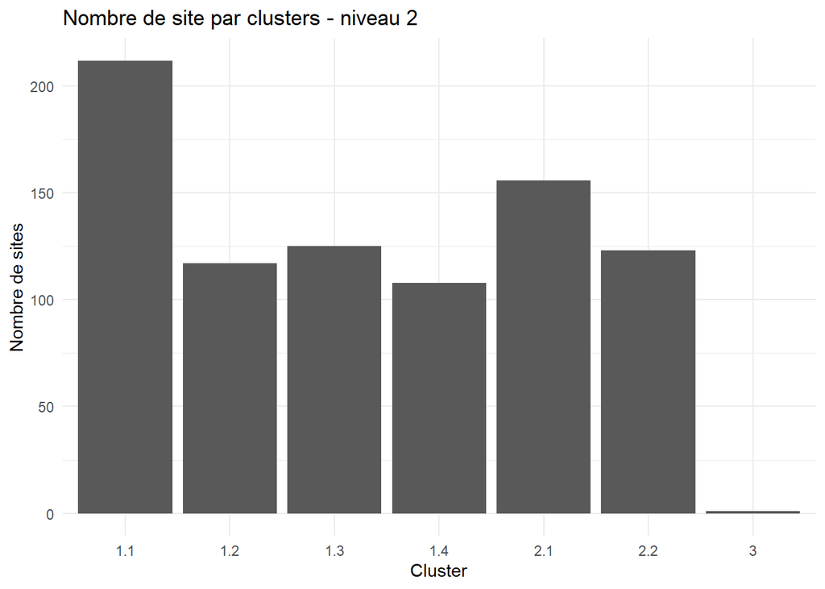

```r
sites_p2 <- plyr::count(site_clusters1[3])
ggplot(sites_p2, aes(x = K_7, y = freq)) +
  geom_bar(stat = "identity") +
  labs(x = "Cluster", y = "Nombre de sites") +
  theme_minimal() +
  ggtitle("Nombre de site par clusters - niveau 2")
```

On voit que les 2 grands clusters du niveau 1 et les 6 grands clusters du niveau 2 ont tous un grand nombre de sites, comparables en taille. En revanche, le petit cluster n’a qu’un seul site - il s’agit probablement d’une zone avec des espèces endémiques trouvées nulle part ailleurs dans le monde.

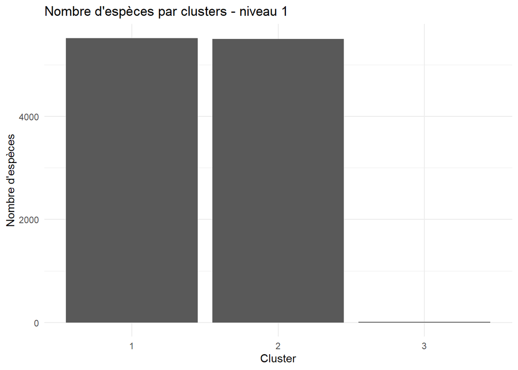

```r
species_clusters1 <- clusters1[which(clusters1$ID %in% fishdb1$Species), ]
species_p1 <- plyr::count(species_clusters1[2]) # 2e colonne = première partition / premier niveau
ggplot(species_p1, aes(x = K_3, y = freq)) +
  geom_bar(stat = "identity") +
  labs(x = "Cluster", y = "Nombre d'espèces") +
  theme_minimal() +
  ggtitle("Nombre d'espèces par clusters - niveau 1")
```

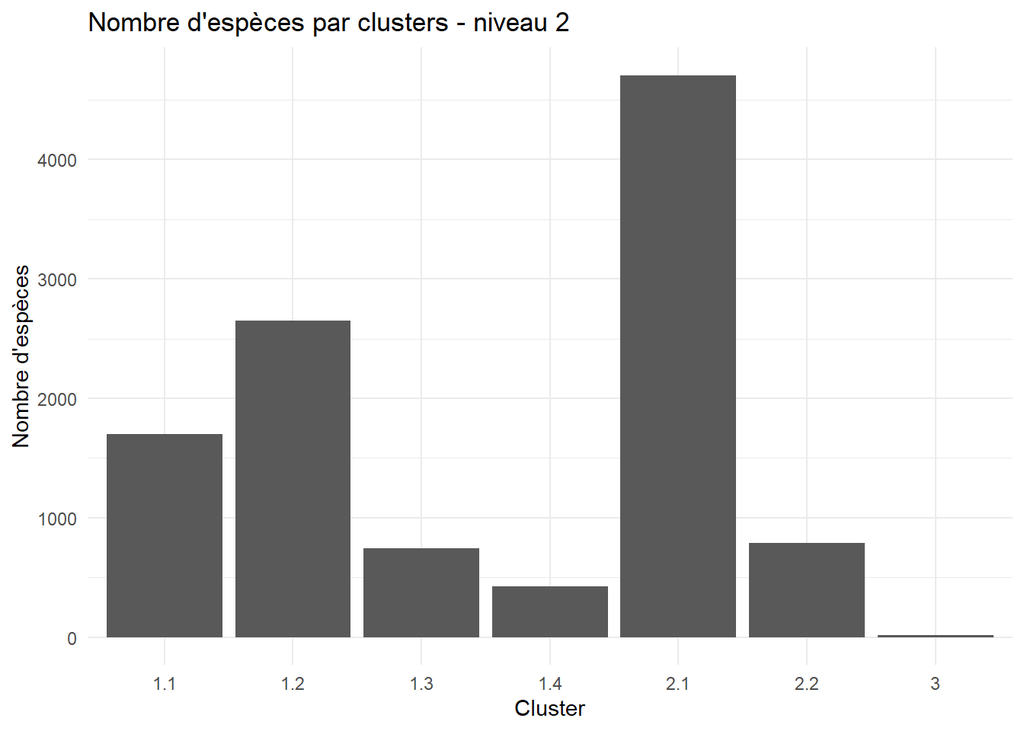

```r
species_p2 <- plyr::count(species_clusters1[3]) # 3e colonne = deuxième partition / second niveau
ggplot(species_p2, aes(x = K_7, y = freq)) +
  geom_bar(stat = "identity") +
  labs(x = "Cluster", y = "Nombre d'espèces") +
  theme_minimal() +
  ggtitle("Nombre d'espèces par clusters - niveau 2")
```

Les 2 clusters de niveau 1 sont à peu près équilibré en nombre d’espèces, tandis que les clusters de niveau 2 sont plus déséquilibrés : il y a des régions très riches (jusque 4700 espèces), et d’autres très pauvres (seulement 400 espèces).

# 5. Faites une carte des régions

## 5.1 Assigner une couleur à chaque région

```r
fish_clusters1 <- bioregion_colors(fish_clusters1,
                                   palette = "Safe",
                                   cluster_ordering = "n_both")
```

## 5.2 Faire la carte

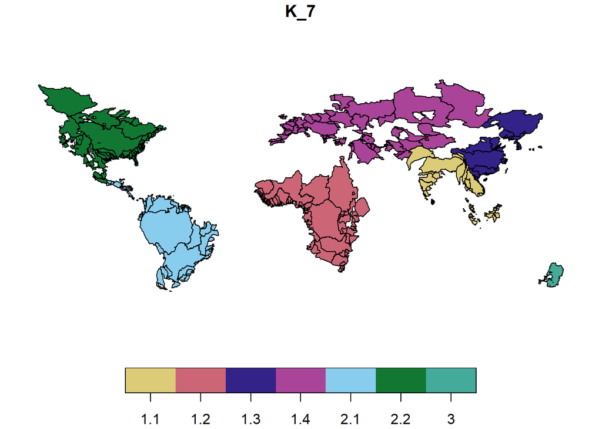

```r
map_bioregions(bioregionalization = fish_clusters1,
               map = basins,
               partition_index = 3)
```

# 6. Ecrire le réseau biogéographique pour Gephi

```r
exportGDF(df = fishdb1,
          col1 = "Basin",
          col2 = "Species",
          weight = NULL,
          bioregions = fish_clusters1,
          bioregionalization = 2,
          file = "data/fish1.gdf")
```

```
## Using partition 2 ('K_7') for cluster assignments and colors.
```

# 7. Analysez le réseau biogéographique sous gephi

La visualisation sous Gephi se fait à partir du fichier généré à l’étape 6.

# 8. Refaites l’analyse pour la seconde base de données

```r
fish_clusters2 <- netclu_infomap(net = fishdb2,
                                 weight = FALSE,
                                 binpath = "c:/r",
                                 numtrials = 100,
                                 show_hierarchy = TRUE,
                                 bipartite = TRUE,
                                 bipartite_version = FALSE,
                                 site_col = "Basin",
                                 species_col = "Species",
                                 seed = 123)
fish_clusters2
```

```
## Clustering results for algorithm : netclu_infomap
##  - Number of sites:  842
## Clustering results:
##  - Number of partitions:  4
##  - Partitions are hierarchical
##  - Number of clusters:  4 44 94 99
```

```r
summary(fish_clusters2)
```

```
##
## Summary of clustering results
## =============================
##
## Algorithm:  netclu_infomap
## Number of sites:  842
##   - Site nodes:  842
##   - Species nodes:  11033
## Number of bioregionalizations:  4
## Hierarchical clustering: Yes
##
## Bioregionalization 1: K_4
## -------------------------
## Total clusters:  4
## Top 4 clusters by size:
##   Cluster 2: 4859 items (156 sites, 4703 species)
##   Cluster 1: 4190 items (565 sites, 3625 species)
##   Cluster 3: 2762 items (117 sites, 2645 species)
##   Cluster 4: 64 items (4 sites, 60 species)
##
## Bioregionalization 2: K_44
## --------------------------
## Total clusters:  44
## Top 10 clusters by size:
##   Cluster 1.1: 1846 items (203 sites, 1643 species)
##   Cluster 1.2: 1408 items (228 sites, 1180 species)
##   Cluster 2.3: 1139 items (1 sites, 1138 species)
##   Cluster 1.3: 936 items (134 sites, 802 species)
##   Cluster 2.4: 674 items (2 sites, 672 species)
##   Cluster 3.4: 556 items (1 sites, 555 species)
##   Cluster 2.7: 500 items (1 sites, 499 species)
##   Cluster 3.1: 495 items (59 sites, 436 species)
##   Cluster 2.1: 395 items (22 sites, 373 species)
##   Cluster 3.5: 386 items (2 sites, 384 species)
##   ... and 34 more cluster(s)
##
## Bioregionalization 3: K_94
## --------------------------
## Total clusters:  94
## Top 10 clusters by size:
```

[output cut: 83 more lines]

```
## ├─3.14 (n=1)
## │ └─3.14 (n=1)
## ├─3.15 (n=24)
## │ └─3.15 (n=24)
## ├─3.16 (n=25)
## │ └─3.16 (n=25)
## ├─3.17 (n=1)
## │ └─3.17 (n=1)
## ├─3.2 (n=275)
## │ └─3.2 (n=275)
## └─... and 7 more
##
## 4 (n=64)
## └─4 (n=64)
##   └─4 (n=64)
```

```r
fish_clusters2 <- bioregion_colors(fish_clusters2,
                                   palette = "Vivid",
                                   cluster_ordering = "n_both")


png("comparison_map.png", width = 800, height = 400)
par(mfrow = c(1,2))
map_bioregions(bioregionalization = fish_clusters1,
               map = basins,
               partition_index = 2,
               main = "fishdb1")


map_bioregions(bioregionalization = fish_clusters2,
               map = basins,
               partition_index = 2,
               main = "fishdb2")
dev.off()
```

```r
exportGDF(df = fishdb2,
          col1 = "Basin",
          col2 = "Species",
          weight = NULL,
          bioregions = fish_clusters2,
          bioregionalization = 1,
          file = "data/fish2.gdf")
```

```
## Using partition 1 ('K_4') for cluster assignments and colors.
```

**Question** Qu’est-ce qui peut expliquer la différence entre les deux bases de données ?

La différence est due au fait que la base fishdb2 intègre les occurrences d’introduction par l’homme des poissons d’eau douce, ce qui masque les patrons naturels et change la forme des régions biogéographiques de poissons d’eau douce.

# 9. Calculer et comparer les métriques d’endemisme entre les deux bases de données

```r
fishmat1 <- net_to_mat(fishdb1)
endemism1 <- bioregionalization_metrics(bioregionalization = fish_clusters1,
                                        dissimilarity = NULL,
                                        comat = fishmat1,
                                        eval_metrics = c("mean_endemics", "tot_endemics"))

fishmat2 <- net_to_mat(fishdb2)
endemism2 <- bioregionalization_metrics(bioregionalization = fish_clusters2,
                                        dissimilarity = NULL,
                                        comat = fishmat2,
                                        eval_metrics = c("mean_endemics", "tot_endemics"))
# Endémisme des régions naturelles
endemism1
```

```
##       partition n_bioregions mean_endemics tot_endemics
## K_3         K_3            3     0.9998790    0.9999093
## K_7         K_7            7     0.9232105    0.9749773
## K_83       K_83           83     0.3638454    0.6835902
## K_113     K_113          113     0.3286474    0.6318223
```

```r
# Endémisme des régions avec les introductions
endemism2
```

```
##      partition n_bioregions mean_endemics tot_endemics
## K_4        K_4            4     0.8627068    0.9895767
## K_44      K_44           44     0.3799271    0.7393275
## K_94      K_94           94     0.3119671    0.6631922
## K_99      K_99           99     0.3029538    0.6456993
```

On note une diminution très forte de l’endémisme moyen par région (= proportion moyenne d’espèces endémiques par biorégion) à cause des introductions d’espèces par l’homme. La proportion totale d’espèces endémiques est aussi plus faible, mais dans une moindre mesure.

# 10. (facultatif) Faites une belle carte ʕ◠ᴥ◠ʔ

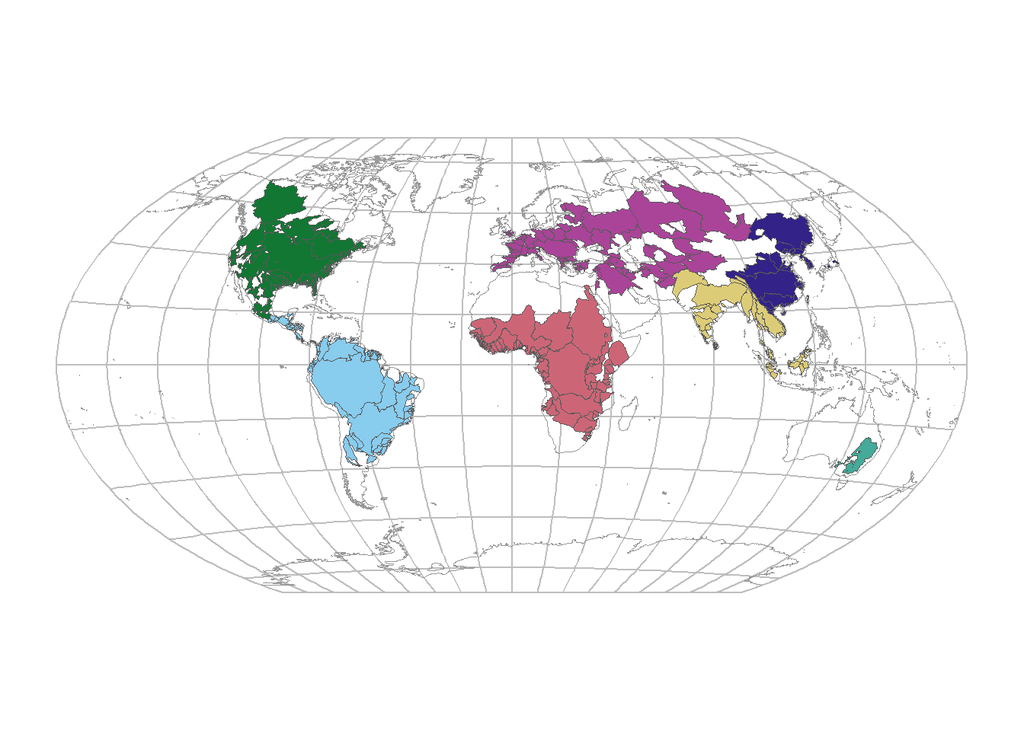

```r
library(lwgeom)
library(ggplot2)
library(rnaturalearth)

# On va utiliser la projection du National Geographic: Winkel Tripel
# Pour cela il faut utiliser le package lwgeom qui permet des projections additionnelles avec sf

# Graticule
gr <- sf::st_graticule(lat = c(-89.9,seq(-80,80,20), 89.9))
# Projection du graticule en wintri
gr <- st_transform_proj(gr,
                        crs = "+proj=wintri")

# Trait de cote
wm <- ne_coastline(scale = 50, returnclass = "sf")
# Projection
wm <- st_transform_proj(wm,
                        crs = "+proj=wintri")


# Projection des bassins en wintri
basins <- st_transform_proj(basins,
                             crs = "+proj=wintri")

basins$color1 <-
  fish_clusters1$clusters_colors[
        match(basins$BasinName,
              fish_clusters1$clusters_colors$ID), 3] # couleur du niveau 2
basins$color2 <-
  fish_clusters2$clusters_colors[
        match(basins$BasinName,
              fish_clusters2$clusters_colors$ID), 2] # couleur du niveau 1

ggplot() +
  geom_sf(data = gr, color = 'grey', # graticule
          size = .5) +
  geom_sf(data = wm, col = grey(.6), fill = grey(.9), # continents
          size = .2) +
  geom_sf(data = basins, aes(fill = color1), # bassins avec couleurs des régions
          size = .05) +
  theme_minimal() + # thème simplifié pour ggplot2
  coord_sf(datum = NA) + # obligatoire pour pouvoir utiliser les projections de lwgeom
  scale_fill_identity()  # pour que ggplot utilise bien les couleurs qu'on lui demande
```

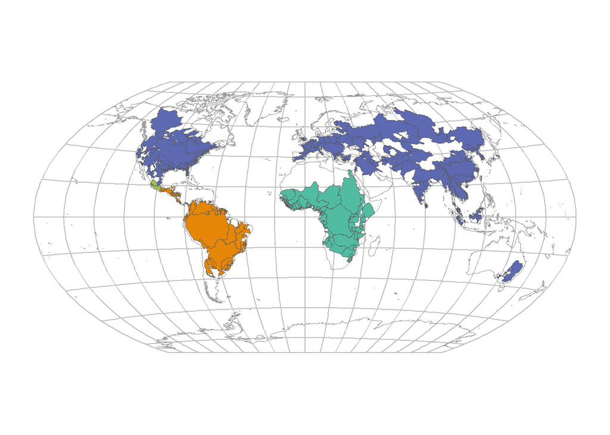

```r
ggplot() +
  geom_sf(data = gr, color = 'grey', # graticule
          size = .5) +
  geom_sf(data = wm, col = grey(.6), fill = grey(.9), # continents
          size = .2) +
  geom_sf(data = basins, aes(fill = color2), # bassins avec couleurs des régions
          size = .05) +
  theme_minimal() + # thème simplifié pour ggplot2
  coord_sf(datum = NA) + # obligatoire pour pouvoir utiliser les projections de lwgeom
  scale_fill_identity()  # pour que ggplot utilise bien les couleurs qu'on lui demande
```